# Exercise: Regularization and Bayesian Shrinkage

Ridge, Lasso, and Horseshoe Priors

Author

Alexander Massey

Published

April 2, 2026

**NoteOverview**

This exercise develops a unified view of penalized regression and Bayesian shrinkage through three connected parts. The core insight is that every penalized regression method corresponds to a Bayesian model with a specific prior on the coefficients — the penalty parameter $\lambda$ is not a nuisance to be selected by cross-validation but a parameter with a statistical interpretation.

**Parts 1 and 2** use simulated data with a known ground truth. Simulation lets you verify the theoretical equivalence numerically and compare estimates to the truth directly.

**Part 3** uses the prostate cancer dataset (Stamey et al., 1989) — a real dataset with genuine partial sparsity where lasso and horseshoe outperform ridge.

[output not shown]

## 1 Simulation

The simulation is designed so that ridge regularization genuinely helps: high within-block correlation ($\rho = 0.9$), predictors on different scales, and a moderate signal-to-noise ratio. With this design the GCV curve has a clear interior minimum around $\lambda \approx 7$–$8$.

```r
library(MASS)
library(brms)
library(tidyverse)
library(loo)

# ── 1. Simulation ──────────────────────────────────────────────────────
set.seed(42)
n <- 250; p <- 15
blk <- function(rho, k) { M <- matrix(rho, k, k); diag(M) <- 1; M }
Sigma <- as.matrix(Matrix::bdiag(blk(0.9, 5), blk(0.9, 5), blk(0.9, 5)))
X_raw <- MASS::mvrnorm(n, mu = rep(0, p), Sigma = Sigma)
# Variables with different scales = different CI widths
scales <- seq(1, 4, length.out = p)
X_sim  <- sweep(X_raw, 2, scales, "*")
beta_true <- c(1.2, 1, -1, 0.8, -0.6, 0.7, -0.7, 0.5, -0.4, 0.3, 0.3, -0.2, 0.2, -0.1, 0)
y_sim  <- as.numeric(X_sim %*% beta_true + rnorm(n, sd = 4))
df_sim <- data.frame(y = y_sim, X_sim)
# ───────────────────────────────────────────────────────────────────────
original_means <- colMeans(df_sim)      # keep the means to backtransform later
original_sds   <- apply(df_sim, 2, sd)  # keep the sds too
sd_y <- original_sds["y"]
sd_x <- original_sds[names(original_sds) != "y"]
df_sim     <- as.data.frame(scale(df_sim))  # standardize dataset
beta_true  <- beta_true * (sd_x / sd_y)     # scale the true coefficients for the plot
# ───────────────────────────────────────────────────────────────────────
```

## 2 Part 1 — Ridge Regression as a Bayesian Normal-Normal Model

### 2.1 The Mathematical Correspondence

Ridge regression solves:

$$\min_{\boldsymbol{\beta}} \; \|\mathbf{y} - \mathbf{X}\boldsymbol{\beta}\|^2 + \lambda\|\boldsymbol{\beta}\|^2$$

A Bayesian linear model with Normal priors on coefficients has the following specification:

$$\mathbf{y} \mid \boldsymbol{\beta}, \sigma \sim \mathcal{N}(\mathbf{X}\boldsymbol{\beta},\; \sigma^2 \mathbf{I}_n)$$

$$\beta_j \sim \mathcal{N}(0, \tau^2) \quad \text{for } j = 1, \ldots, p$$

The negative log-posterior is:

$$-\log p(\boldsymbol{\beta} \mid \mathbf{y}) = \frac{\|\mathbf{y} - \mathbf{X}\boldsymbol{\beta}\|^2}{2\sigma^2} + \frac{\|\boldsymbol{\beta}\|^2}{2\tau^2} + \text{const}$$

Comparing the MAP objective to the ridge objective gives the exact identity:

$$\boxed{\lambda = \frac{\sigma^2}{\tau^2} \qquad \Longleftrightarrow \qquad \tau = \frac{\sigma}{\sqrt{\lambda}}}$$

**NoteWhy lm.ridge?**

We use `lm.ridge` (MASS package) throughout Parts 1 and 2 because it minimizes $\|\mathbf{y} - \mathbf{X}\boldsymbol{\beta}\|^2 + \lambda\|\boldsymbol{\beta}\|^2$ directly with no $1/(2n)$ normalization. This means the identity $\lambda = \sigma^2/\tau^2$ holds with no scaling correction. The `glmnet` package divides by $2n$, which would require an additional factor of $n$ in the correspondence.

### 2.2 Code

#### 2.2.1 Step 1 — Select $\lambda$ by GCV

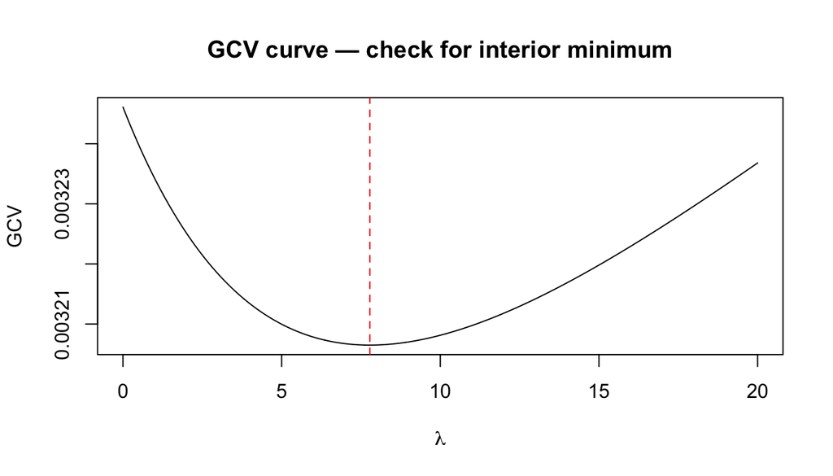

```r
# We find lambda via Generalized Cross-Validation (GCV)
ridge_grid <- lm.ridge(y ~ ., data = df_sim, lambda = seq(0, 20, by = .01))

# Always plot the GCV curve before accepting the minimum
plot(ridge_grid$lambda, ridge_grid$GCV, type = "l",
     xlab = expression(lambda), ylab = "GCV",
     main = "GCV curve — check for interior minimum")
abline(v = as.numeric(names(which.min(ridge_grid$GCV))), col = "red", lty = 2)
```

```r
lambda_gcv <- as.numeric(names(which.min(ridge_grid$GCV)))
cat("GCV lambda:", lambda_gcv)
```

```
GCV lambda: 7.78
```

```r
# Fit ridge at the selected lambda
ridge_fit <- lm.ridge(y ~ ., data = df_sim, lambda = lambda_gcv)
```

#### 2.2.2 Step 2 — Derive $\sigma$ and $\tau$

```r
# Estimate sigma from OLS (unbiased, uses n-p-1 df correction)
ols_fit   <- lm(y ~ ., data = df_sim)
sigma_est <- summary(ols_fit)$sigma

# tau from the correspondence: lambda = sigma^2 / tau^2
tau_est <- sigma_est / sqrt(lambda_gcv)

cat("sigma_est:", round(sigma_est, 4))
```

```
sigma_est: 0.8753
```

```r
cat("tau_est:  ", round(tau_est,   4))
```

```
tau_est:   0.3138
```

```r
cat("Verify — sigma^2/tau^2 =", round(sigma_est^2 / tau_est^2, 4),
    "== lambda_gcv:", lambda_gcv)
```

```
Verify — sigma^2/tau^2 = 7.78 == lambda_gcv: 7.78
```

#### 2.2.3 Step 3 — Fit two Bayesian models

We fit two models to make the shrinkage contrast explicit. The first uses brms default priors, making it essentially equivalent to OLS. The second uses the $\tau$ derived from GCV and pins $\sigma$, making it equivalent to ridge.

```r
# Model 1: OLS-like Bayes — brms default priors, sigma free
fit_ols_b <- brm(
  y ~ ., data = df_sim,
  chains  = 2, iter = 2000, refresh = 0, backend = "rstan"
)

# Model 2: Empirical Bayes — ridge-informed prior, sigma pinned
# tau comes from GCV; sigma is fixed so MAP = ridge solution
fit_eb <- brm(
  y ~ ., data = df_sim,
  prior = c(
    set_prior(paste0("normal(0, ", round(tau_est, 6), ")"), class = "b"),
    set_prior(paste0("normal(", round(sigma_est, 4), ", 0.001)"), class = "sigma")
    # set_prior("exponential(1)", class = "sigma")  # uncomment for Question 4
  ),
  chains = 2, iter = 4000, refresh = 0, backend = "rstan"
)
```

#### 2.2.4 Step 4 — Compare all methods

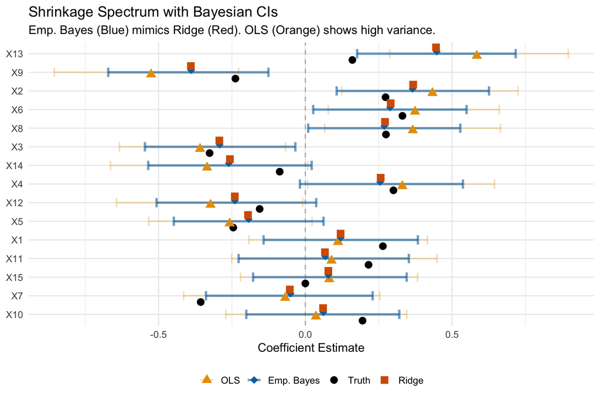

```r
# Plot wrapper functions exist but it we will make our own
# mcmc_plot(fit_eb, type = "dens_overlay", prob = .85, prob_outer = 0.95)

res_ols_b <- fixef(fit_ols_b)[-1, ]
res_eb    <- fixef(fit_eb)[-1, ]

results <- tibble(
  Predictor = paste0("X", 1:p),
  Truth     = beta_true,
  Ridge     = coef(ridge_fit)[-1],
  OLS       = res_ols_b[, "Estimate"],
  OLS_L     = res_ols_b[, "Q2.5"],
  OLS_U     = res_ols_b[, "Q97.5"],
  EB_Est    = res_eb[, "Estimate"],
  EB_L      = res_eb[, "Q2.5"],
  EB_U      = res_eb[, "Q97.5"]
) %>%
  pivot_longer(cols = c(Truth, OLS, EB_Est, Ridge),
               names_to = "Method", values_to = "Estimate") %>%
  mutate(Method = case_when(
    Method == "EB_Est" ~ "Emp. Bayes",
    Method == "OLS"    ~ "OLS",
    TRUE ~ Method
  )) %>%
  mutate(Method = factor(Method, levels = c("Truth", "OLS", "Emp. Bayes", "Ridge")))

ggplot(results, aes(x = reorder(Predictor, abs(Estimate)),
                    y = Estimate, color = Method, shape = Method)) +
  geom_hline(yintercept = 0, linetype = "dashed", color = "grey70") +
  # OLS credible intervals — wide, showing high variance
  geom_errorbar(data = filter(results, Method == "OLS"),
                aes(ymin = OLS_L, ymax = OLS_U),
                width = 0.5, linewidth = 0.8, alpha = 0.3,
                position = position_dodge(width = 0.9)) +
  # Emp. Bayes credible intervals — narrower after shrinkage
  geom_errorbar(data = filter(results, Method == "Emp. Bayes"),
                aes(ymin = EB_L, ymax = EB_U),
                width = 0.5, linewidth = 1.2, alpha = 0.6,
                position = position_dodge(width = 0.9)) +
  geom_point(size = 3.5, position = position_dodge(width = 0.9)) +
  scale_color_manual(values = c(Truth = "black", OLS = "#E69F00",
                                `Emp. Bayes` = "#0072B2", Ridge = "#D55E00")) +
  scale_shape_manual(values = c(Truth = 16, OLS = 17, `Emp. Bayes` = 18, Ridge = 15)) +
  coord_flip() +
  labs(title   = "Shrinkage Spectrum with Bayesian CIs",
       subtitle = "Emp. Bayes (Blue) mimics Ridge (Red). OLS (Orange) shows high variance.",
       x = NULL, y = "Coefficient Estimate") +
  theme_minimal(base_size = 13) +
  theme(legend.position = "bottom", legend.title = element_blank())
```

### 2.3 Exercises

**Q1.1** Demonstrate that the simulated data is multicollinear. Inspect the correlation structure visually and numerically.

**TipHint**

- Use `pairs(df_sim[, 1:6])` to visualize pairwise scatterplots for the first block.
- Use `cor(df_sim[, -1])` to compute the full correlation matrix. Which pairs of predictors have the highest correlation?
- Compute the condition number of $\mathbf{X}'\mathbf{X}$ using `kappa(t(X_sim) %*% X_sim)`. A condition number much greater than 30 indicates problematic multicollinearity for OLS.

**Q1.2** Plot the GCV curve before selecting $\lambda$. Is the minimum clearly interior ($\lambda > 0$), or does GCV decrease monotonically toward zero? What would a monotonically decreasing GCV curve tell you about the suitability of ridge regularization? The initial grid search used steps of 0.01. How would you refine it further?

**TipHint**

- $\lambda = 0$ means no penalty at all — the ridge solution collapses to OLS. A GCV minimum at zero means regularization does not help.
- Refine the grid near the minimum: `ridge_grid2 <- lm.ridge(y ~ ., data = df_sim, lambda = seq(lambda_gcv - 1, lambda_gcv + 1, by = 0.001))`. Does the selected $\lambda$ change?
- The block correlation structure ($\rho = 0.9$) is designed to produce a genuine interior minimum.

**Q1.3** Verify that OLS and its Bayesian equivalent (`fit_ols_b`) produce the same coefficient estimates. What happens if you use brms default priors instead of specifying them explicitly? Then address: (a) Why are some shrinkage estimates larger than the true values? (b) Why are Ridge and Emp. Bayes not exactly the same?

**TipHint**

- Compare `summary(ols_fit)` to `fixef(fit_ols_b)`. Use `prior_summary(fit_ols_b)` to inspect the default priors.
- 1. Shrinkage always pulls toward zero, not toward the truth. If OLS overestimates a coefficient due to multicollinearity, ridge pulls it back toward zero — which may overshoot or undershoot the truth. On standardized data, Ridge and Emp. Bayes should agree closely because both operate on the same scale.
- 2. Shrinkage reduces mean squared error on average across all coefficients, but individual coefficients can end up further from the truth than OLS if the OLS error happened to be in the direction of the truth.

**Q1.4** Free $\sigma$ by replacing the pinned prior with `set_prior("exponential(1)", class = "sigma")` in `fit_eb` and refit. What is the estimated sigma? Would you would expect more or less regularization for smaller $n$?

**TipHint**

- GCV and full Bayes optimize different things. GCV minimizes an estimate of out-of-sample prediction error and explicitly penalizes model complexity through the hat matrix. brms with a free $\sigma$ finds the posterior most consistent with the data and prior jointly — with a weak enough prior on $\beta$, the likelihood dominates and the posterior concentrates near the MLE (OLS).
- The key insight: $\tau$ and $\sigma$ are coupled through $\lambda = \sigma^2/\tau^2$. You cannot free one without changing the implied $\lambda$.
- Smaller sample sizes generally lead to more regularization (i.e., stronger shrinkage of the coefficients toward zero). The model relies more on the prior assumptions (regularization) to avoid overfitting.

## 3 Part 2 — Choosing $\tau$: A Bayesian Model Comparison

### 3.1 Motivation

Part 1 back-calculated $\tau$ from a GCV-selected $\lambda$. This is unsatisfying from a Bayesian perspective — it uses the data twice and frames $\tau$ as a derived frequentist quantity rather than a genuine prior belief.

The fully coherent approach would be to place a prior on $\tau$ itself and let the posterior update it. This requires writing $\tau$ into Stan’s `parameters` block so that it is sampled alongside the coefficients — straightforward in raw Stan, but outside the scope of this exercise.

Instead, we take a practical approach that stays within brms: fit three models with different fixed values of $\tau$ and use leave-one-out cross-validation (LOO) to ask which $\tau$ the data prefer. This is Bayesian model comparison — no frequentist quantity is involved.

**ImportantLOO vs GCV — Are They Really Different?**

Both LOO model comparison and GCV use the data to select the hyperparameter controlling shrinkage. In ridge regression with GCV you search over $\lambda$ and pick the one with best predictive error. With LOO you search over $\tau$ and pick the one with best predictive density. The mechanics differ but the epistemology is the same: **you are using the data to choose your prior**, which is the definition of empirical Bayes.

The added value of LOO is honesty about uncertainty: when `elpd_diff` is smaller than $2 \times$ SE across models, the data genuinely cannot distinguish between the two. Be aware though that the SE is based on a normal approximation which requires adequate sample sample size. In any case, GCV would have given you a point estimate of $\lambda$ and hidden that uncertainty entirely.

### 3.2 The Three Models

All three models share the same likelihood and the same prior on $\sigma$. They differ only in $\tau$, the scale of the Normal prior on coefficients. On standardized data, $\tau$ encodes a prior belief about typical coefficient magnitude.

$$\beta_j \sim \mathcal{N}(0, \tau^2), \quad \sigma \sim \text{Exponential}(1)$$

| Model | $\tau$ | Prior belief |
| --- | --- | --- |
| Tight | 0.07 | Most coefficients $< 0.07$ in absolute value |
| Moderate | 0.4 | Most coefficients $< 0.4$ |
| Loose | 100 | Essentially flat — approaches OLS |

Note that $\tau$ is fixed in each model, not estimated. The LOO comparison selects which fixed $\tau$ the data prefer. This corresponds to ridge penalties $\lambda = \sigma^2/\tau^2$ of roughly 204, 6, and near-zero respectively (using $\sigma \approx 1$).

### 3.3 Code

```r
library(loo)

# Model 1: tight prior — strong shrinkage
fit_tight <- brm(
  y ~ ., data = df_sim,
  prior = c(
    prior(normal(0, 0.07), class = b),
    prior(exponential(1), class = sigma)
  ),
  chains = 2, iter = 4000, warmup = 1000,
  seed = 1, backend = "rstan", refresh = 0,
  save_pars = save_pars(all = TRUE)
)

# Model 2: moderate prior — weakly informative
fit_mod <- brm(
  y ~ ., data = df_sim,
  prior = c(
    prior(normal(0, 0.4), class = b),
    prior(exponential(1), class = sigma)
  ),
  chains = 2, iter = 4000, warmup = 1000,
  seed = 1, backend = "rstan", refresh = 0,
  save_pars = save_pars(all = TRUE)
)

# Model 3: loose prior — near-OLS
fit_loose <- brm(
  y ~ ., data = df_sim,
  prior = c(
    prior(normal(0, 100), class = b),
    prior(exponential(1), class = sigma)
  ),
  chains = 2, iter = 4000, warmup = 1000,
  seed = 1, backend = "rstan", refresh = 0,
  save_pars = save_pars(all = TRUE)
)
```

```r
# Compute LOO for each model
loo_tight <- loo(fit_tight)
loo_mod   <- loo(fit_mod)
loo_loose <- loo(fit_loose)

# Compare — higher ELPD (less negative) is better
# A difference smaller than 2*SE is not worth interpreting
loo_compare(loo_tight, loo_mod, loo_loose)
```

```
          elpd_diff se_diff
fit_mod     0.0       0.0
fit_loose  -1.5       1.2
fit_tight -11.3       5.6
```

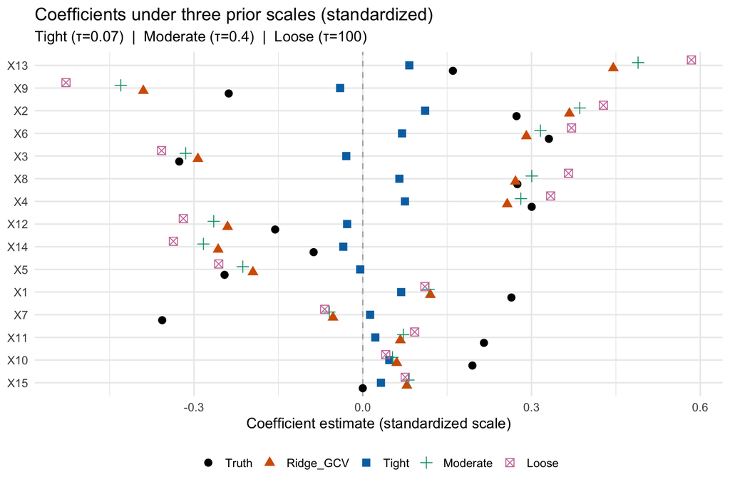

```r
# Plot 1 — standardized scale
fe_tight <- fixef(fit_tight)
fe_mod   <- fixef(fit_mod)
fe_loose <- fixef(fit_loose)

preds <- paste0("X", 1:p)

coef_comp <- tibble(
  Predictor = preds,
  Truth     = beta_true,
  Ridge_GCV = coef(ridge_fit)[-1],
  Tight     = fe_tight[preds, "Estimate"],
  Moderate  = fe_mod[preds,   "Estimate"],
  Loose     = fe_loose[preds, "Estimate"]
)

coef_comp |>
  pivot_longer(c(Truth, Ridge_GCV, Tight, Moderate, Loose),
               names_to = "Method", values_to = "Estimate") |>
  mutate(Method = factor(Method,
         levels = c("Truth", "Ridge_GCV", "Tight", "Moderate", "Loose"))) |>
  ggplot(aes(x = reorder(Predictor, abs(Estimate)),
             y = Estimate, color = Method, shape = Method)) +
  geom_hline(yintercept = 0, linetype = "dashed", color = "grey70") +
  geom_point(size = 3, position = position_dodge(0.6)) +
  coord_flip() +
  scale_color_manual(values = c(Truth = "black", Ridge_GCV = "#D55E00",
                                Tight = "#0072B2", Moderate = "#009E73",
                                Loose = "#CC79A7")) +
  labs(title   = "Coefficients under three prior scales (standardized)",
       subtitle = "Tight (τ=0.07)  |  Moderate (τ=0.4)  |  Loose (τ=100)",
       x = NULL, y = "Coefficient estimate (standardized scale)") +
  theme_minimal(base_size = 13) +
  theme(legend.position = "bottom", legend.title = element_blank())
```

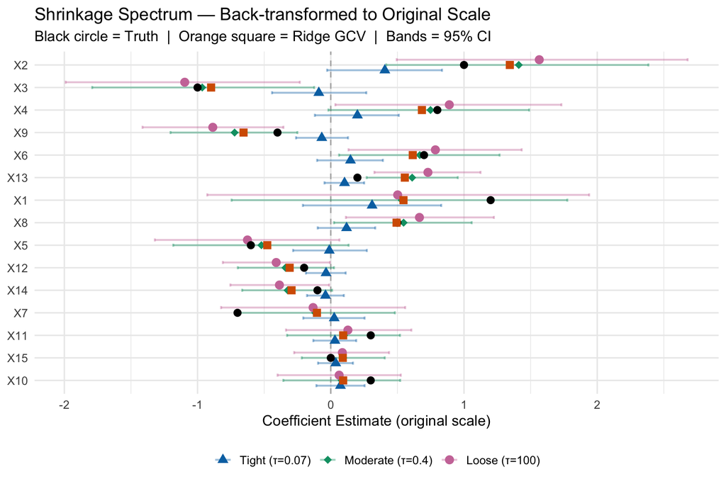

```r
# Plot 2 — back-transformed to original scale
bt_fixef <- function(fit, model_name) {
  fe <- fixef(fit)
  fe <- fe[rownames(fe) != "Intercept", ]
  tibble(
    Predictor = paste0("X", 1:p),
    Method    = model_name,
    Estimate  = fe[, "Estimate"] * (sd_y / sd_x),
    L         = fe[, "Q2.5"]    * (sd_y / sd_x),
    U         = fe[, "Q97.5"]   * (sd_y / sd_x)
  )
}

results_p2 <- bind_rows(
  bt_fixef(fit_tight, "Tight (τ=0.07)"),
  bt_fixef(fit_mod,   "Moderate (τ=0.4)"),
  bt_fixef(fit_loose, "Loose (τ=100)")
) |>
  mutate(Method = factor(Method,
         levels = c("Tight (τ=0.07)", "Moderate (τ=0.4)", "Loose (τ=100)")))

# Reference points: truth and ridge on original scale
ref <- tibble(
  Predictor = paste0("X", 1:p),
  Truth     = beta_true * (sd_y / sd_x),
  Ridge_GCV = coef(ridge_fit)[-1] * (sd_y / sd_x)
)

ggplot(results_p2,
       aes(x = reorder(Predictor, abs(Estimate)),
           y = Estimate, color = Method, shape = Method)) +
  geom_hline(yintercept = 0, linetype = "dashed", color = "grey70") +
  geom_errorbar(aes(ymin = L, ymax = U),
                width = 0.4, linewidth = 0.8, alpha = 0.4,
                position = position_dodge(width = 0.7)) +
  geom_point(size = 3, position = position_dodge(width = 0.7)) +
  geom_point(data = ref, aes(x = Predictor, y = Truth),
             color = "black", shape = 16, size = 3, inherit.aes = FALSE) +
  geom_point(data = ref, aes(x = Predictor, y = Ridge_GCV),
             color = "#D55E00", shape = 15, size = 3, inherit.aes = FALSE) +
  coord_flip() +
  scale_color_manual(values = c("Tight (τ=0.07)"    = "#0072B2",
                                "Moderate (τ=0.4)" = "#009E73",
                                "Loose (τ=100)"    = "#CC79A7")) +
  scale_shape_manual(values = c("Tight (τ=0.07)"    = 17,
                                "Moderate (τ=0.4)" = 18,
                                "Loose (τ=100)"    = 19)) +
  labs(title   = "Shrinkage Spectrum — Back-transformed to Original Scale",
       subtitle = "Black circle = Truth  |  Orange square = Ridge GCV  |  Bands = 95% CI",
       x = NULL, y = "Coefficient Estimate (original scale)") +
  theme_minimal(base_size = 13) +
  theme(legend.position = "bottom", legend.title = element_blank())
```

### 3.4 Exercises

**Q2.1** Run `loo_compare()` on the three models. Which $\tau$ does LOO prefer? Is the difference in ELPD larger than $2 \times$ SE, making it meaningful? How does the LOO-preferred $\tau$ compare to `tau_est` from Part 1?

**TipHint**

- `loo_compare()` ranks models by ELPD (expected log predictive density). The top row is the best model; differences are relative to it.
- A difference smaller than $2 \times$ SE is not worth interpreting — the models are predicting essentially equally well.
- If the LOO scores are nearly identical, this is itself informative: the data cannot distinguish between the three priors for prediction purposes.

**Q2.2** When two models have `elpd_diff` within $2 \times$ SE, which should you prefer — the more regularized model or the weak prior? Why?

**TipHint**

- From a pure prediction standpoint, prefer the more regularized model. When two models predict equally well in LOO, the regularized one tends to be more stable on genuinely new data.
- The weak prior model is fitting noise that happened to be in your training data. Among models with equal predictive performance, prefer the simpler one (Occam’s razor).
- The one exception: if you have strong subject-matter reasons to believe some coefficients are genuinely large and the tight prior is suppressing them — but you would see that in the coefficient plot.

**Q2.3** Compare the coefficient plots across the three models and ridge. Which predictors change the most as $\tau$ decreases from 100 to 0.07? Are the large-signal predictors (X1, X2) robust to the choice of $\tau$?

**TipHint**

- Predictors with small true coefficients (X13, X14, X15) should be most affected — tight priors shrink them hardest toward zero.
- Large-signal predictors (X1, X2) should be robust — the likelihood dominates the prior for those coefficients.
- If the LOO winner matches ridge closely, it confirms that GCV and Bayesian model comparison extract similar information from the data.

**Q2.4** Add a fourth model using `tau = tau_est` from Part 1 (the GCV-implied value). Where does it rank in the LOO comparison? Does this confirm or challenge the idea that GCV and Bayesian model comparison agree?

**TipHint**

```r
fit_gcv <- brm(
  y ~ ., data = df_sim,
  prior = c(
    set_prior(paste0("normal(0, ", tau_est,")"), class = "b"),
    set_prior("exponential(1)", class = "sigma")
  ),
  chains = 2, iter = 4000, warmup = 1000,
  seed = 1, backend = "rstan", refresh = 0,
  save_pars = save_pars(all = TRUE)
)

loo(...)
loo_compare(...)
```

- If the GCV-tau model ranks at or near the top, both methods are selecting the same level of regularization from the data.
- This is the cleanest bridge between Parts 1 and 2: GCV picks a $\lambda$, and Bayesian LOO confirms it is a good choice.

## 4 Part 3 — Lasso and Horseshoe on the prostate Cancer Data

### 4.1 The Dataset

```r
data(prostate, package = "genridge")

# Standardize all predictors and response
pros <- prostate |>
  mutate(across(everything(), scale)) |>
  mutate(across(everything(), as.numeric))

# OLS as a reference point
ols_pros <- lm(lpsa ~ ., data = pros)
summary(ols_pros)
```

```
Call:
lm(formula = lpsa ~ ., data = pros)

Residuals:
     Min       1Q   Median       3Q      Max
-1.53158 -0.30886 -0.00378  0.32900  1.35068

Coefficients:
              Estimate Std. Error t value Pr(>|t|)
(Intercept) -8.321e-16  6.188e-02   0.000  1.00000
lcavol       5.763e-01  9.025e-02   6.386 8.08e-09 ***
lweight      2.309e-01  7.504e-02   3.077  0.00279 **
age         -1.374e-01  7.342e-02  -1.872  0.06460 .
lbph         1.217e-01  7.345e-02   1.657  0.10113
svi          2.731e-01  8.704e-02   3.138  0.00233 **
lcp         -1.282e-01  1.098e-01  -1.168  0.24609
gleason      3.126e-02  9.944e-02   0.314  0.75401
pgg45        1.083e-01  1.096e-01   0.989  0.32558
train        1.652e-03  6.551e-02   0.025  0.97994
---
Signif. codes:  0 '***' 0.001 '**' 0.01 '*' 0.05 '.' 0.1 ' ' 1

Residual standard error: 0.6095 on 87 degrees of freedom
Multiple R-squared:  0.6634,    Adjusted R-squared:  0.6286
F-statistic: 19.05 on 9 and 87 DF,  p-value: < 2.2e-16
```